# Topic Modeling in NLP - Topic modeling - 3

One should look for what is and not what he thinks should be. (Albert Einstein)

# Module completion checklist

| Objective | Complete |
| --- | --- |
| Perform latent dirichlet allocation (LDA) on frequency counts |  |
| Evaluate results and choose optimal number of topics |  |

# Create a dictionary of counts

- Let’s create the dictionary using `gensim.corpora.Dictionary` and look at our output using a small loop

```python
# Set the seed.
np.random.seed(1)
dictionary = gensim.corpora.Dictionary(df_clean)

# The loop below iterates through the first 10 items of the dictionary and prints out the key and value.
count = 0
for k, v in dictionary.iteritems():
    print(k, v)
    count += 1
    if count > 10:
        break
```

```
0 american
1 battl
2 brisban
3 defens
4 harrison
5 kyrgio
6 nick
7 open
8 round
9 ryan
10 start
```

# Create a dictionary of counts

- We can filter out words by their frequency in the dictionary
- `.filter_extremes()` will remove all values in the dictionary that are:
  - less frequent than `no_below` documents
  - more than `no_above` documents (fraction of total corpus size, not absolute number)
  - keep only first `keep_n` most frequent tokens

```python
dictionary.filter_extremes(no_below = 4, no_above = 0.5, keep_n = 200)

# How many words are left in the dictionary?
len(dictionary)
```

```
200
```

# Document to bag-of-words

- Now we will use `gensim` library `doc2bow` to transform each document to a dictionary
- Each document will become a dictionary that has the number of words and has the number of times each of those words appear
- This is the object we will use to build our TF-IDF matrix

```python
# We use a list comprehension to transform each doc within our df_clean object.
bow_corpus = [dictionary.doc2bow(doc) for doc in df_clean]

# Let's look at the first document.
print(bow_corpus[0])
```

```
[(0, 1), (1, 1), (2, 2), (3, 1), (4, 1), (5, 1), (6, 1)]
```

# Document to bag-of-words (cont’d)

- Let’s preview bag-of-words for the first document

```python
# Isolate the first document.
bow_doc_1 = bow_corpus[0]

# Iterate through each dictionary item using the index.
# Print out each actual word and how many times it appears.
for i in range(len(bow_doc_1)):
    print("Word {} (\"{}\") appears {} time.".format(bow_doc_1[i][0],

          dictionary[bow_doc_1[i][0]],
          bow_doc_1[i][1]))
```

```
Word 0 ("american") appears 1 time.
Word 1 ("defens") appears 1 time.
Word 2 ("open") appears 2 time.
Word 3 ("round") appears 1 time.
Word 4 ("start") appears 1 time.
Word 5 ("tuesday") appears 1 time.
Word 6 ("victori") appears 1 time.
```

# Transform counts with TfidfModel

- To transform a Document-Term Matrix, which is a “bag-of-words” representation `bow_corpus` that we created above, into `TF-IDF`, we will use `TfidfModel` from `gensim` library’s `model` module for working with text

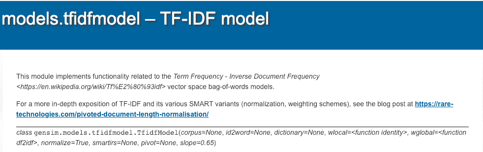

# Transform counts with TfidfModel (cont’d)

- We will now activate the `TfidfModel` function and transform our `bow_corpus`
- Our output will be the TF-IDF transformation applied to each document:

$$TF \times IDF = \frac{F_{wd}}{N_{d}}
\times log \frac{M}{M_{w}}$$

```python
# This is the transformation.
tfidf = models.TfidfModel(bow_corpus)

# Apply the transformation to the entire corpus.
corpus_tfidf = tfidf[bow_corpus]

# Preview TF-IDF scores for the first document.
for doc in corpus_tfidf:
    pprint(doc)
    break
```

```
[(0, 0.31942373876087665),
 (1, 0.3549009519669791),
 (2, 0.6118718565633235),
 (3, 0.3549009519669791),
 (4, 0.3059359282816618),
 (5, 0.22829905152454918),
 (6, 0.3549009519669791)]
```

# LDA on `snippet`

We need the following data objects for topic modeling:

- `df_clean`: the corpus, where:
  - each ‘document’ is one entry in `snippet`
  - each document is cleaned, and punctuation, numbers, special characters and stop words removed
- `dictionary`: a dictionary containing the **number of times a given word appears** within the entire corpus
- `corpus_tfidf`: a Document-Term Matrix (DTM) transformed to be a weighted term frequency - inverse document frequency matrix

Let’s apply the idea of LDA to our corpus of **snippet**

# LDA with the gensim package

- We will continue using `gensim` and now introduce `models.LdaMulticore`

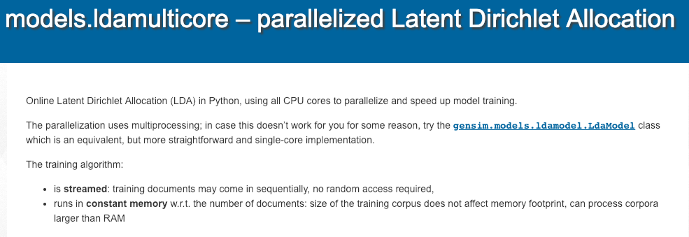

# LdaMulticore

- We run the LdaMulticore model using:

```
gensim.models.ldamulticore.LdaMulticore(corpus = None,
                                        num_topics = 100,
                                        id2word = None, workers = None,
                                        passes = 1)
```

- Before running the model, let’s make sure we understand the main parameters of the model:
  - `corpus`: stream of document vectors or sparse matrix of shape
  - `num_topics`: default is 100, make sure to change according to number of topics you decide on
  - `id2word`: mapping from word IDs to words
  - `workers`: number of cores being used, if `None` then all available cores will be used
  - `passes`: number of passes through the corpus during training, e.g., how many times to classify each word to each topic

# Running LdaMulticore

- Let’s run the model on our transformed matrix `corpus_tfidf` using `dictionary` as the `id2word` object

```python
lda_model_tfidf = gensim.models.LdaMulticore(corpus_tfidf,
                                             num_topics = 5,
                                             id2word = dictionary,
                                             workers = 4,
                                             passes = 2)
```

- We have our `LdaMulticore` object now

```python
print(lda_model_tfidf)
```

```
LdaMulticore<num_terms=200, num_topics=5, decay=0.5, chunksize=2000>
```

# LDA output

- We chose 5 topics, we are now going to print out each topic and the top words within the topics

```python
for idx, topic in lda_model_tfidf.print_topics(-1):
    print('Topic: {} Word: {}'.format(idx, topic))
```

```
Topic: 0 Word: 0.020*"offici" + 0.020*"like" + 0.017*"say" + 0.017*"week" + 0.017*"warn" + 0.015*"show" + 0.015*"state" + 0.014*"thursday" + 0.014*"help" + 0.014*"new"
Topic: 1 Word: 0.023*"time" + 0.023*"latest" + 0.022*"world" + 0.021*"local" + 0.020*"new" + 0.016*"year" + 0.015*"meet" + 0.013*"york" + 0.013*"tenni" + 0.013*"leader"
Topic: 2 Word: 0.021*"said" + 0.020*"friday" + 0.018*"billion" + 0.018*"know" + 0.015*"set" + 0.015*"say" + 0.013*"accus" + 0.012*"want" + 0.012*"govern" + 0.012*"court"
Topic: 3 Word: 0.020*"investig" + 0.020*"saturday" + 0.019*"presid" + 0.017*"polic" + 0.014*"said" + 0.014*"expect" + 0.013*"citi" + 0.013*"suspect" + 0.013*"year" + 0.013*"first"
Topic: 4 Word: 0.022*"young" + 0.020*"tuesday" + 0.018*"look" + 0.018*"said" + 0.016*"talk" + 0.016*"close" + 0.015*"move" + 0.015*"new" + 0.015*"south" + 0.014*"year"
```

- We can interpret this by looking at the top words by topic
  - These are the words that contribute most to each topic
- This is a very raw version of the output, we are going to learn more about how to clean this up and interpret it later!

# Classify our documents within topics

- Let’s see how we would classify our df_clean as one of the five topics

```python
# Let's look at our first document as an example:
print(df_clean[0])
```

```
['nick', 'kyrgio', 'start', 'brisban', 'open', 'titl', 'defens', 'battl', 'victori', 'american', 'ryan', 'harrison', 'open', 'round', 'tuesday']
```

```python
for index, score in sorted(lda_model_tfidf[corpus_tfidf[0]], key=lambda tup: -1*tup[1]):
    print("\nScore: {}\t \nTopic: {}".format(score, lda_model_tfidf.print_topic(index, 10)))
```

```
Score: 0.7646151185035706
Topic: 0.020*"investig" + 0.020*"saturday" + 0.019*"presid" + 0.017*"polic" + 0.014*"said" + 0.014*"expect" + 0.013*"citi" + 0.013*"suspect" + 0.013*"year" + 0.013*"first"

Score: 0.060962967574596405
Topic: 0.020*"offici" + 0.020*"like" + 0.017*"say" + 0.017*"week" + 0.017*"warn" + 0.015*"show" + 0.015*"state" + 0.014*"thursday" + 0.014*"help" + 0.014*"new"

Score: 0.058861665427684784
Topic: 0.022*"young" + 0.020*"tuesday" + 0.018*"look" + 0.018*"said" + 0.016*"talk" + 0.016*"close" + 0.015*"move" + 0.015*"new" + 0.015*"south" + 0.014*"year"
```

# Module completion checklist

| Objective | Complete |
| --- | --- |
| Perform latent dirichlet allocation (LDA) on frequency counts | **✔** |
| Evaluate results and choose optimal number of topics |  |

# LDA: evaluate results

- How do we evaluate our LDA model?
- The measure we will focus on in this module is **topic coherence**
- With **topic coherence**, we will be able to evaluate our results as well as build a plot that will help us choose the optimal number of topics for our LDA model
- The function we will use is from the `gensim` package, `CoherenceModel`
- You can read the paper [“Exploring the space of topic coherence measures”](http://svn.aksw.org/papers/2015/WSDM_Topic_Evaluation/public.pdf) for an in-depth understanding of topic coherence

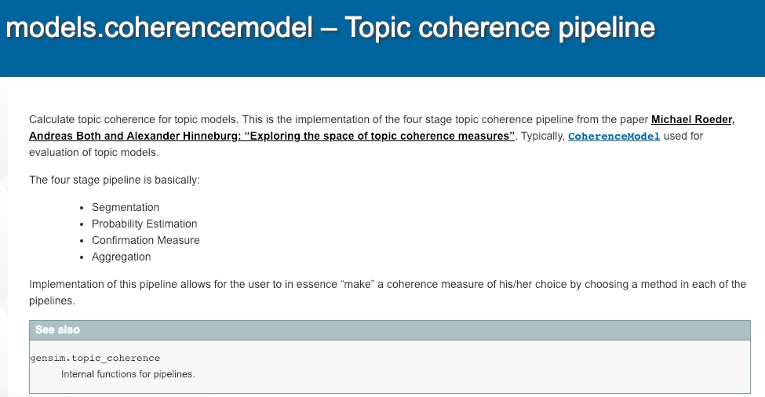

# Topic coherence: quick overview

- Topic coherence is based on four main concepts
  - Segmentation: dividing the topics into smaller subsets
  - Probability estimation: quantitative measure of the subtopic quality
  - Confirmation measure: determine quality based on some predefined measure
  - Aggregation: combine all quality numbers and derive one number for overall quality
- There are two measures in topic coherence
  - **Intrinsic** : compares a word only to the preceding and succeeding words respectively, so you need the ordered word set for this. It uses a pairwise score function which is the empirical conditional log-probability with smoothing count
  - **Extrinsic** : every single word is paired with every other single word
- Both intrinsic and extrinsic measures compute the coherence score `c`

# Calculate topic coherence

- We will now calculate topic coherence on our `lda_model_tfidf`
- The parameters we need are:
  - original doc, `df_clean`
  - dictionary built of the corpora, `dictionary`
  - lda model, `lda_model_tfidf`
  - coherence metric, `c_v` (based on the [paper](http://svn.aksw.org/papers/2015/WSDM_Topic_Evaluation/public.pdf) referenced above)

```python
# Compute Coherence Score using c_v.
coherence_model_lda = CoherenceModel(model = lda_model_tfidf, texts = df_clean, dictionary = dictionary, coherence = 'c_v')
coherence_lda = coherence_model_lda.get_coherence()
```

```python
print('Coherence Score: ', coherence_lda)
```

```
Coherence Score:  0.5082391247655911
```

# Find optimal topic number

- We see we have a pretty low coherence score
- We can look at the coherence score for a range of topic numbers and choose the optimal topic number
- We now build a function that will allow us compute `c_v` coherence for various number of topics
- The parameters are:
  - `dictionary` : Gensim dictionary
  - `corpus` : Gensim corpus
  - `texts` : list of input texts
  - `limit` : max num of topics

# Convenience function

- Here’s a convenience function to run LDA and compute coherence values:

```python
def compute_coherence_values(dictionary, corpus, texts, limit, start = 2, step = 3):
    coherence_values = []
    model_list = []
    for num_topics in range(start, limit, step):
        model = gensim.models.LdaMulticore(corpus = corpus,
                                           id2word = dictionary, num_topics = num_topics)
        model_list.append(model)
        coherencemodel = CoherenceModel(model = model, texts = texts,
                                        dictionary = dictionary, coherence = 'c_v')
        coherence_values.append(coherencemodel.get_coherence())

    return model_list, coherence_values
```

- The output of the function is:
  - `model_list` : list of LDA topic models
  - `coherence_values` : coherence values corresponding to the LDA model with respective number of topics

# Run compute_coherence_values function

```python
np.random.seed(1)
model_list, coherence_values = compute_coherence_values(dictionary = dictionary,
                                                        corpus = corpus_tfidf,
                                                        texts = df_clean,
                                                        start = 2,
                                                        limit = 40,
                                                        step = 6)
```

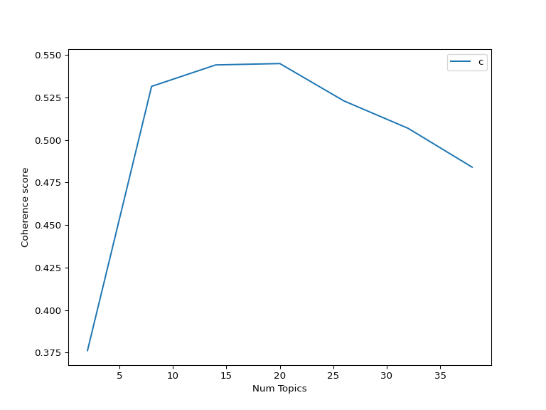

```python
# Plot graph of topic list.
# Show graph.

limit = 40; start = 2; step = 6;
x = range(start, limit, step)
plt.plot(x, coherence_values)
plt.xlabel("Num Topics")
plt.ylabel("Coherence score")
plt.legend(("coherence_values"), loc = 'best')
plt.show()
```

# Final thoughts

- **What do you think the optimal number of topics looks like?**
- A couple takeaways about LDA:
  - LDA does better with more text, larger pieces of text / documents
  - Sentiment analysis would do well on a smaller amount of data like what we have here

# Knowledge check

# Module completion checklist

| Objective | Complete |
| --- | --- |
| Perform latent dirichlet allocation (LDA) on frequency counts | **✔** |
| Evaluate results and choose optimal number of topics | **✔** |

# Congratulations on completing this module!

You are now ready to try Tasks 6-9 in the Exercise for this topic